# R Notebook

$H_1 :$ $The$ $true$ $correlation$ $is$ $not$ $equal$ $to$ $0$

$The$ $p-value$ $shows$ $that$ $we$ $reject$ $H_0$ $hypothesis$ $and$ $correlation$ $between$ $right-$ $eyesight$ $and$ $being$ $smoker/non-smoker$ $is$ $not$ $0$.

$The$ $same$ $for$ $left-eyesight.$

$However$ $the$ $correlation$ $coefficient$ $is$ $close$ $to$ $0$ $\to$ $there$ $is$ $weak$ $positive$ $relation$ $between$ $eyesight$ $and$ $being$ $smoker/non-smoker$.

```r
right.eyesight <- data$eyesight.right.
left.eyesight <- data$eyesight.left.
people <- data$smoking
cor.test(people, right.eyesight, method = "kendall")
cor.test(people, left.eyesight, method = "kendall")
```

[output not shown]

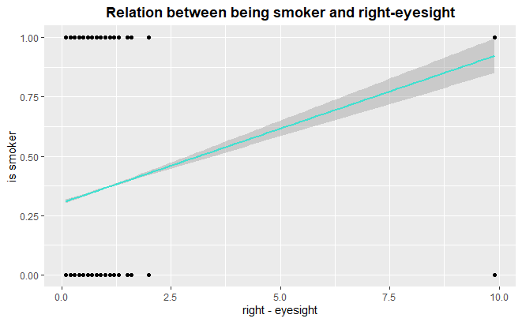

```r
library("ggplot2")
ggplot(data,aes(right.eyesight, people)) +
  geom_point() +
  geom_smooth(method='lm', color='turquoise')  + labs(x='right - eyesight', y='is smoker', title='Relation between being smoker and right-eyesight') +
  theme(plot.title = element_text(hjust=0.5, face='bold'))
```

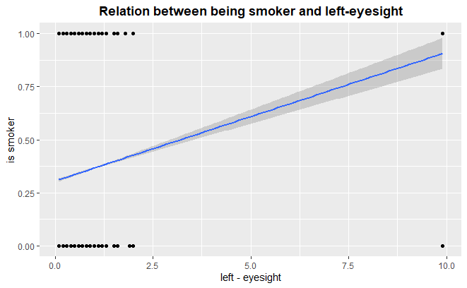

```r
ggplot(data,aes(left.eyesight, people)) +
  geom_point() +
  geom_smooth(method='lm')  +  labs(x='left - eyesight', y='is smoker', title='Relation between being smoker and left-eyesight') +
  theme(plot.title = element_text(hjust=0.5, face='bold'))
```

```r
eyesight_model.right <- lm(smoking~right.eyesight, data=data)
summary(eyesight_model.right)
```

```
Call:
lm(formula = smoking ~ right.eyesight, data = data)

Residuals:
    Min      1Q  Median      3Q     Max
-0.9232 -0.3668 -0.3481  0.6207  0.6894

Coefficients:
               Estimate Std. Error t value Pr(>|t|)
(Intercept)    0.304311   0.004692   64.85   <2e-16 ***
right.eyesight 0.062512   0.004195   14.90   <2e-16 ***
---
Signif. codes:  0 ‘***’ 0.001 ‘**’ 0.01 ‘*’ 0.05 ‘.’ 0.1 ‘ ’ 1

Residual standard error: 0.4811 on 55690 degrees of freedom
Multiple R-squared:  0.003971,  Adjusted R-squared:  0.003953
F-statistic:   222 on 1 and 55690 DF,  p-value: < 2.2e-16
```

```r
eyesight_model.left <- lm(smoking~left.eyesight, data=data)
summary(eyesight_model.left)
```

```
Call:
lm(formula = smoking ~ left.eyesight, data = data)

Residuals:
    Min      1Q  Median      3Q     Max
-0.9059 -0.3665 -0.3483  0.6214  0.6880

Coefficients:
              Estimate Std. Error t value Pr(>|t|)
(Intercept)   0.305923   0.004705   65.02   <2e-16 ***
left.eyesight 0.060600   0.004188   14.47   <2e-16 ***
---
Signif. codes:  0 ‘***’ 0.001 ‘**’ 0.01 ‘*’ 0.05 ‘.’ 0.1 ‘ ’ 1

Residual standard error: 0.4812 on 55690 degrees of freedom
Multiple R-squared:  0.003746,  Adjusted R-squared:  0.003728
F-statistic: 209.4 on 1 and 55690 DF,  p-value: < 2.2e-16
```

$Also$ $we$ $decided$ $to$ $test$ $relation$ $between$ $other$ $health$ $parameters$ $of$ $smokers/non-smokers.$ $The$ $testing$ $is$ $the$ $same$ $as$ $we$ $did$ $of$ $hypothesis$ $5.$

$Hypothesis$ $6:$ $There$ $is$ $no$ $relation$ $between$ $blood sugar$ $and$ $cholesterol$ $of$ $smokers.$

$H_0 :$ $The$ $true$ $correlation$ $is$ $equal$ $to$ $0$

$H_1 :$ $The$ $true$ $correlation$ $is$ $not$ $equal$ $to$ $0$

$The$ $p-value > 0.05$ $,so$ $we$ $don't$ $reject$ $H_0$

```r
ggplot(data.smokers,aes(data.smokers$fasting.blood.sugar, data.smokers$Cholesterol)) +
  geom_point() +
  geom_smooth(method='lm', color='turquoise')  + labs(x='blood sugar', y='cholesterol', title='Relation between cholestorol and blood sugar of smokers') +
  theme(plot.title = element_text(hjust=0.5, face='bold'))
```

[output not shown]

```r
cor.test(data.smokers$fasting.blood.sugar, data.smokers$Cholesterol)
```

```
    Pearson's product-moment correlation

data:  data.smokers$fasting.blood.sugar and data.smokers$Cholesterol
t = 1.3468, df = 20453, p-value = 0.1781
alternative hypothesis: true correlation is not equal to 0
95 percent confidence interval:
 -0.004287911  0.023118016
sample estimates:
        cor
0.009416821
```

$Hypothesis$ $7:$ $There$ $is$ $no$ $relation$ $between$ $blood sugar$ $and$ $cholesterol$ $of$ $non-smokers.$

$H_0 :$ $The$ $true$ $correlation$ $is$ $equal$ $to$ $0$

$H_1 :$ $The$ $true$ $correlation$ $is$ $not$ $equal$ $to$ $0$

$The$ $p-value < 0.05$ $\to$ $we$ $reject$ $H_0.$ $The$ $correlation$ $is$ $close$ $to$ $0$ $\to$ $weak$ $positive$ $relation.$

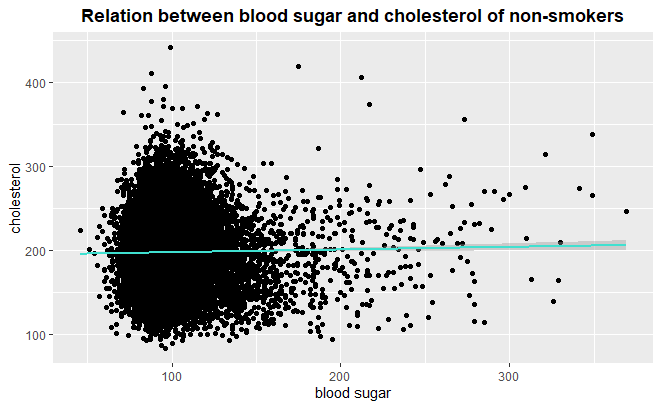

```r
ggplot(data.nonsmokers,aes(data.nonsmokers$fasting.blood.sugar, data.nonsmokers$Cholesterol)) +
  geom_point() +
  geom_smooth(method='lm', color='turquoise')  + labs(x='blood sugar', y='cholesterol', title='Relation between blood sugar and cholesterol of non-smokers') + theme(plot.title = element_text(hjust=0.5, face='bold'))
```

```r
cor.test(data.nonsmokers$fasting.blood.sugar, data.nonsmokers$Cholesterol)
```

```
    Pearson's product-moment correlation

data:  data.nonsmokers$fasting.blood.sugar and data.nonsmokers$Cholesterol
t = 2.9731, df = 35235, p-value = 0.00295
alternative hypothesis: true correlation is not equal to 0
95 percent confidence interval:
 0.005396299 0.026273507
sample estimates:
       cor
0.01583663
```

$Hypothesis$ $8:$ $There$ $is$ $no$ $relation$ $between$ $hemoglobin$ $and$ $cholesterol$ $of$ $smokers.$

$H_0 :$ $The$ $true$ $correlation$ $is$ $equal$ $to$ $0$

$H_1 :$ $The$ $true$ $correlation$ $is$ $not$ $equal$ $to$ $0$

$The$ $p-value < 0.05$ $,so$ $we$ $reject$ $H_0$

$The$ $correlation$ $coeficient$ $is$ $close$ $to$ $0$ $\to$ $relation$ $is$ $weak$ $positive$ $correlated$

```r
ggplot(data.smokers,aes(data.smokers$hemoglobin, data.smokers$Cholesterol)) +
  geom_point() +
  geom_smooth(method='lm', color='turquoise')  + labs(x='hemoglobin', y='cholesterol', title='Relation between hemoglobin and cholesterol value  of smokers')
```

[output not shown]

```r
cor.test(data.smokers$hemoglobin, data.smokers$Cholesterol)
```

[output not shown]

$Hypothesis$ $9:$ $There$ $is$ $no$ $relation$ $between$ $hemoglobin$ $and$ $cholesterol$ $of$ $non-smokers.$

$H_0 :$ $The$ $true$ $correlation$ $is$ $equal$ $to$ $0$

$H_1 :$ $The$ $true$ $correlation$ $is$ $not$ $equal$ $to$ $0$

$The$ $p-value < 0.05$ $,so$ $we$ $reject$ $H_0$

$The$ $correlation$ $coeficient$ $is$ $close$ $to$ $0$ $\to$ $relation$ $is$ $weak$ $positive$ $correlated$

```r
ggplot(data.nonsmokers,aes(data.nonsmokers$hemoglobin, data.nonsmokers$Cholesterol)) +
  geom_point() +
  geom_smooth(method='lm', color='turquoise')  + labs(x='hemoglobin', y='cholesterol', title='Relation between hemoglobin and cholesterol value  of non-smokers')
```

[output not shown]

```r
cor.test(data.nonsmokers$hemoglobin, data.nonsmokers$Cholesterol)
```

```
    Pearson's product-moment correlation

data:  data.nonsmokers$hemoglobin and data.nonsmokers$Cholesterol
t = 8.8929, df = 35235, p-value < 2.2e-16
alternative hypothesis: true correlation is not equal to 0
95 percent confidence interval:
 0.03689972 0.05773540
sample estimates:
       cor
0.04732271
```

The distribution of smoker’s age wasn’t difficult to predict and our hypothesis was approved, however it was surprising that distribution of smokers/non-smokers ration is exponential.

During this research we used our theoretical knowledge on practice, almost all testing methods and linear-regression; and discovered how it works in the real testing of data. We analyze interesting data set for us, because we were curious if the impact of smoking is so crucial on this huge sample of population. In fact it doesn’t make such a crucial impact, but still have harm for our health.